# Lesson176 · Few-shot ICL evaluation

Build an auditable nested-support experiment. Complete three TODOs, then rescore every prediction in both tracks. The default is a complete saved-evidence replay with no paid calls. Fresh author inference is reported separately. Your mastery remains PENDING_WRITTEN_DEFENSE.

```python
# @colab-bootstrap
import importlib.util, subprocess, sys
needed=[name for name,module in [('numpy','numpy'),('torch','torch'),('pyyaml','yaml')] if importlib.util.find_spec(module) is None]
if needed: subprocess.check_call([sys.executable,'-m','pip','install',*needed])
import numpy as np
from pathlib import Path
import json
```

**One win:** design and audit a few-shot evaluation in which increasing the label budget preserves the examples already shown. About 20 minutes; the notebook is a separate practice session.

[174: change parameters](https://avistian.github.io/relational/lessons/0174-fine-tuning-protocol.html) → [175: audit information access](https://avistian.github.io/relational/lessons/0175-zero-shot-evaluation.html) → **176: vary labeled context** → 177: account for compute.

## 1 · A frozen model can still learn from examples

Lesson 174 adapted model parameters. Lesson 175 froze them, then found that the original RT sampler violated its declared event-time bound. That experiment stopped before model inference. Freezing weights did not make its inputs safe.

Now make **permitted labeled context** explicit. A *support set* contains examples with known answers. A *query set* contains the cases whose answers the model must predict. In-context learning (ICL) changes predictions by changing the support input while leaving pretrained parameters fixed. “Zero gradient updates” therefore does not mean “zero labels.” [RDB-PFN §6.1 and Appendix A.3](https://arxiv.org/html/2603.03805v5#A3).

We return to RDB-PFN's released DFS pipeline from lessons 166–169. Deep Feature Synthesis (DFS) turns relational neighborhoods into typed aggregate features. This is a separate pipeline from RT; its results do not repair lesson 175's failure. The selected tasks are F1 driver-DNF and trial study-outcome, with all **702 and 825 test queries** respectively.

Here (k) means **total labeled support rows per task**, shared by all queries. It is not (k) per class, per query, or per database table. All five support sizes—64, 128, 256, 512, 1,024—are called few-shot in the source protocol. No (k=0) result is implied.

## 2 · Follow one support label through the model

**Read the shapes.** k is the number of support examples, F the number of features, and Q the number of queries. Thus `[k,F]` is a table with k rows and F columns. An attention operation mixes representations from allowed positions; its mask blocks the other positions. In the diagram, “keys and values” are attention's matching and content vectors, not database primary and foreign keys. GELU is the smooth nonlinear activation inside the feed-forward update; FFN abbreviates that feed-forward network.

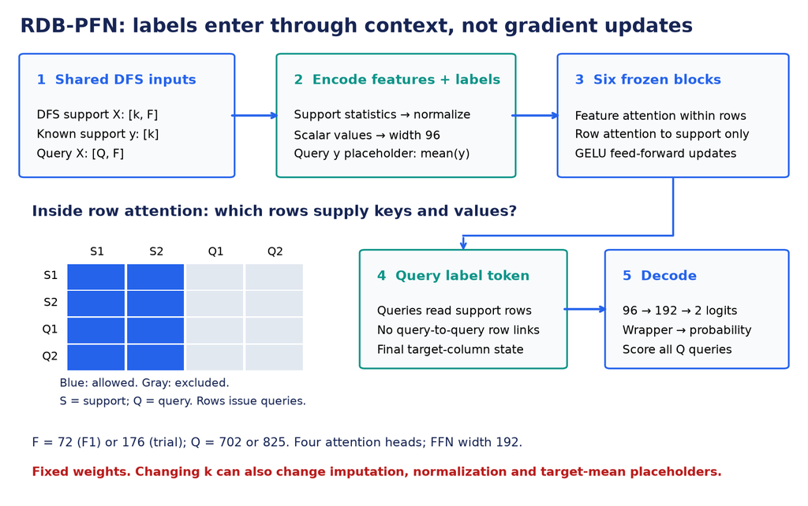

Actual RDB-PFN support/query computation: support-derived feature and label encodings, six frozen attention blocks, and query decoding. TabICL is a separate comparator. Scroll horizontally on narrow screens.

The RDB-PFN arms receive `X_support[k,F]`, `y_support[k]`, and `X_query[Q,F]`: F1 has 72 features; trial has 176. The original feature encoder normalizes using support statistics, clips standardized values, and projects each scalar to width 96. A target column carries support labels; query target placeholders use the **support-label mean**, not the hidden query answer. [Released model](https://avistian.github.io/relational/labs/sources/l166/upstream/model_pretrain/src/models.py).

Six blocks alternate attention across columns within a row and attention across rows within a column. During row attention, support rows attend to support rows; query rows attend to support rows. The query label token then goes through a `96 → 192 → 2` decoder. The wrapper produces class probabilities. Both RDB-PFN checkpoints use this architecture, but their pretraining priors differ. TabICL v1.1 is a separate 32-estimator comparator on the same DFS inputs; this diagram does not describe its architecture.

The wrapper's `fit(X_support, y_support)` installs context. It does not run target-task gradient descent. Adding support can change label evidence **and support-fitted preprocessing**. Our estimand—the quantity we intend to measure—is the complete frozen inference pipeline's response to more labeled context. It is not a pure causal estimate of label count with every intermediate representation held fixed.

**Work the preprocessing change before the prediction.** Use one numerical feature and a fixed query value 3. In this tiny illustration, the support expands from `[0,2]` to `[0,2,4,6]`. The released model uses the support population standard deviation:

| Support values | Mean | SD | Encoded query |
| --- | --- | --- | --- |
| 0, 2 | 1 | 1 | (3−1)/1 = 2 |
| 0, 2, 4, 6 | 3 | √5 | (3−3)/√5 = 0 |

The raw query and pretrained weights did not change, but the numerical token supplied to the model did. These sizes make the arithmetic small; they are not additional benchmark runs. **Transfer check:** change only support labels while preserving all feature values. Feature normalization stays fixed, while the label tokens and query's support-label-mean placeholder can change. That separates two input paths without claiming either effect is monotonic.

## 3 · Keep old examples when adding new ones

Lesson 169 reproduced the released sampler: each size used its own random draw without replacement. Reusing a seed did not make those sets nested. A 128-example result could replace many of the 64 examples, mixing a size change with a composition change.

For the new **L176 Nested-Support ICL Evaluation**, draw an ordered set of 1,024 eligible training rows once per task and seed. Use its prefixes at every smaller size. At any size, all three models receive exactly the same ordered support identities.

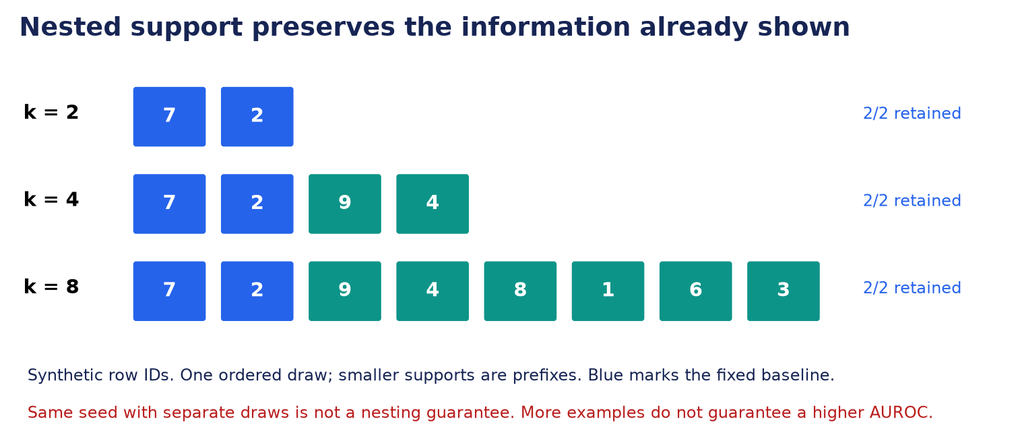

Synthetic worked trace: one ordered draw, three nested prefixes. Baseline rows remain blue; additional rows are green. Scroll horizontally on narrow screens.

A tiny synthetic trace makes the distinction visible. Suppose the ordered draw is `[7,2,9,4,8,1,6,3]`. At (k=2), use `[7,2]`; at (k=4), use `[7,2,9,4]`. Both old examples remain. An independent draw `[8,1,7,6]` retains only one. These toy identifiers explain sampling; they are not measured benchmark rows.

Complete the live nested-support function below.

Each prefix remains a random subset of the requested size, but the dependence *between* sizes changes. That change is declared before inference. Larger contexts can still hurt: additional examples can be misleading, preprocessing can shift, and a model's response need not be monotonic.

Predict: must adding examples improve AUROC? Explain before looking at the measured curve.

## 4 · Freeze the evaluation contract before seeing scores

| Decision | Frozen choice |
| --- | --- |
| Queries | Every released F1/trial test key; no row cap |
| Support candidates | Released training split only; no query answers |
| Size and seeds | Five fixed sizes × seeds 0–9 |
| Models | Two pinned RDB-PFN checkpoints; pinned TabICL v1.1 |
| Fairness | Same ordered support and query keys across models |
| Selection | No test-based choice of model, seed, size, or checkpoint |
| Metric | AUROC per run, then means and sample SD across support draws |

Use complete `(entity_id, cutoff)` keys. An entity may appear at multiple dates; collapsing those rows can silently overwrite answers. Check unique support identities, support/query disjointness, and completed outcome windows **before** dispatch. The conservative inherited horizon checks are 60 days for the released F1 data and 365 for trial; these are retained compatibility checks, not a new claim about RT's 30-day task implementation. [Input preflight](https://avistian.github.io/relational/labs/evidence/l176/preflight.json), [original F1 protocol](https://avistian.github.io/relational/labs/l166-reproduction.md).

The released binary labels complement the raw task labels; preserve their orientation consistently for both targets and probabilities. Existing MAX-timestamp checks cover selected DFS columns. Complete DFS regeneration, historical feature arrival, exact pretraining lineage, and historical identity remain unestablished. Successful support checks alone cannot establish every feature's legality.

## 5 · Pair gains by support draw

For seed (s), compute Δ_s = AUROC(2k,s) − AUROC(k,s). Average these ten differences and report their **sample standard deviation**. Pairing by seed preserves the nested experiment's design. Do not subtract unmatched rows after sorting scores.

For a synthetic three-seed trace, scores `[.60,.70,.80]` at (k) and `[.65,.68,.83]` at (2k) give gains `[+.05,−.02,+.03]`: mean **+.02**, sample SD **.0361**. The average improves even though one seed gets worse. This is an arithmetic example, not our measured result.

These seeds vary support draws on a fixed task. They are not ten independent databases. A sample SD is not a confidence interval or evidence of universal superiority. We show all five sizes without selecting the highest test score as a new tuned configuration.

| Task / frozen model | 64 | 128 | 256 | 512 | 1,024 |
| --- | --- | --- | --- | --- | --- |
| rel-f1/RDBPFN | 0.7066 | 0.7220 | 0.7256 | 0.7192 | 0.7188 |
| rel-f1/RDBPFN_single | 0.6030 | 0.6593 | 0.6579 | 0.6929 | 0.7086 |
| rel-f1/TabICLv1.1 | 0.6999 | 0.7250 | 0.7229 | 0.7202 | 0.7173 |
| rel-trial/RDBPFN | 0.5426 | 0.5677 | 0.5746 | 0.5988 | 0.6159 |
| rel-trial/RDBPFN_single | 0.5127 | 0.5380 | 0.5707 | 0.5843 | 0.5963 |
| rel-trial/TabICLv1.1 | 0.5272 | 0.5610 | 0.5797 | 0.5947 | 0.6087 |

Measured mean AUROC over ten support seeds; every cell contains fresh L176 inference. Sample SD and all paired gains are in the notebook and explorer.

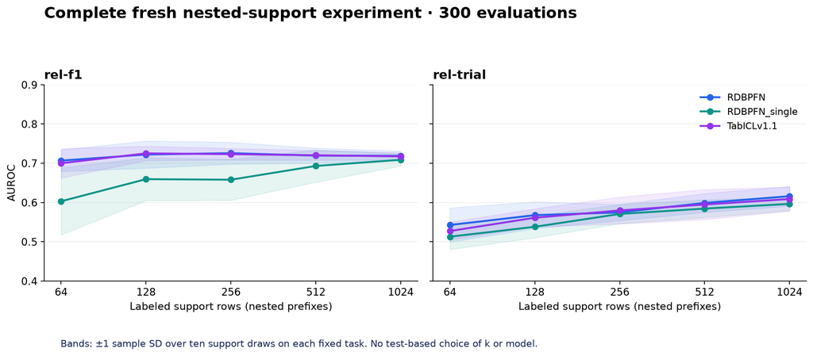

Fresh measured means and sample SD across ten support draws. Both panels use the same AUROC scale. No best-k test selection. Scroll horizontally on narrow screens.

**Observed negative mean doubling gains:** rel-f1/RDBPFN: 256→512 (-0.00634); rel-f1/RDBPFN: 512→1024 (-0.00048); rel-f1/RDBPFN_single: 128→256 (-0.00138); rel-f1/TabICLv1.1: 128→256 (-0.00208); rel-f1/TabICLv1.1: 256→512 (-0.00276); rel-f1/TabICLv1.1: 512→1024 (-0.00284). **21 of 24 adjacent-size contrasts contain both positive and negative seed gains.** These observations describe two fixed tasks and do not establish a universal effect.

## 6 · Keep reproduction and intervention separate

**Track A: published-experiment replay.** Independently authenticate and rescore lesson 169's full 300 selected evaluations: 229,050 saved probabilities. Its original independent support draws and source comparisons remain intact. This is fresh verification of saved evidence, not fresh inference.

**Track B: nested-support experiment.** Execute the complete new 300-evaluation grid and save keyed probabilities, support identities, source hashes, and attempt receipts. Nested sampling is a declared deviation from the released implementation. Agreement at 1,024 examples is a consistency check, not permission to call the smaller nested contexts a paper-table reproduction. [Full contract](https://avistian.github.io/relational/labs/l176-reproduction.md).

**Executed:** all 300 fresh nested evaluations and all 300 saved published-protocol evaluations independently rescored: **458,100 probabilities across the two tracks**. These are repeated predictions on the same two test populations, not 458,100 independent examples. Fresh pretraining and whole-paper reproduction remain `NOT_RUN`; learner status is `PENDING_WRITTEN_DEFENSE`.

Neither track reproduces the whole paper or fresh pretraining. The inherited TabICL exact-repeatability failure remains visible; small numerical discrepancies are not silently relabeled as exact equality. The aggregate cost cap is $10, including failures and overhead. A budget or scientific failure stops execution and yields `INCOMPLETE`, rather than a smaller experiment under the same name.

## 7 · Lab: build the support contract, then defend the curve

[Prepared notebook](https://avistian.github.io/relational/labs/html/0176-few-shot-icl-evaluation.html) · [Student notebook](https://avistian.github.io/relational/labs/0176-few-shot-icl-evaluation.ipynb) · [Reference solution](https://avistian.github.io/relational/labs/solutions/0176-few-shot-icl-evaluation.ipynb) · [Quick reference](https://avistian.github.io/relational/reference/few-shot-icl-evaluation.html).

Complete three live functions: construct nested support, score by complete query keys, and require a complete seed grid before computing paired gains. Checks reject plausible wrong implementations. The portable notebook replays every saved prediction using your functions. Its appendices expose the original model and the full fresh-inference runner; the default does not launch paid work.

**Exit:** choose one observed negative gain or a seed reversal. State the task, model, sizes and seed evidence; explain what changed, what stayed fixed, and why the result neither proves nor disproves a universal benefit from more labels. Add the source/availability limitation that your claim still depends on.

Write your own evaluation card; ask the teacher for feedback.

Read [RDB-PFN Appendix A.3](https://arxiv.org/html/2603.03805v5#A3), then trace its released sampler beside the nested implementation. Ask the agent follow-up questions or paste your evaluation card for feedback. Author execution does not establish learner mastery.

## PROVIDED · Authenticate the complete evidence packet

Includes both full300-evaluation tracks, source files, ordered supports, query keys, labels and raw probabilities. No scores are fetched from an answer service. Hashes detect changed packet bytes; historical source lineage still has the documented limits.

[output not shown]

## TODO · Construct the nested support schedule

Validate positive integer sizes, distinct contexts and a nonempty seed key. Use the first4SHA256bytes as an unsigned big-endian integer. Draw max(contexts) distinct indices with NumPy default_rng, then return a dict of ordered prefixes. Never redraw at smaller k.

```python
def nested_support(n_rows, contexts, seed_key):
    import hashlib
    import numpy as np
    if type(n_rows) is not int or not contexts or any(type(k) is not int or not 0<k<=n_rows for k in contexts) or len(set(contexts))!=len(contexts) or not isinstance(seed_key,str) or not seed_key:
        raise ValueError('Invalid support request')
    seed=int.from_bytes(hashlib.sha256(seed_key.encode()).digest()[:4],'big')
    largest=np.random.default_rng(seed).choice(n_rows,max(contexts),replace=False)
    return {k:largest[:k].copy() for k in contexts}
```

```python
toy=nested_support(20,[2,4,8],'worked:0')
assert np.array_equal(toy[2],toy[8][:2]) and len(set(toy[8]))==8
print('CHECK1: old examples retained',toy)
```

```
CHECK1: old examples retained {2: array([16,  1]), 4: array([16,  1,  3, 14]), 8: array([16,  1,  3, 14, 13,  9, 17,  4])}
```

## TODO · Align complete query keys before ranking

Reject missing/duplicate two-column keys, invalid probabilities and labels lacking either binary class. Align to label keys. Compute the fraction of positive-negative pairs correctly ranked, with half credit for ties.

```python
def keyed_auc(label_keys, labels, prediction_keys, probabilities):
    import numpy as np
    lk=np.asarray(label_keys);pk=np.asarray(prediction_keys);y=np.asarray(labels);p=np.asarray(probabilities,dtype=float)
    if lk.ndim!=2 or pk.ndim!=2 or lk.shape[1]!=2 or pk.shape[1]!=2 or y.shape!=(len(lk),) or p.shape!=(len(pk),):raise ValueError('Invalid keyed arrays')
    left=list(map(tuple,lk));right=list(map(tuple,pk))
    if len(set(left))!=len(left) or len(set(right))!=len(right) or set(left)!=set(right):raise ValueError('Missing or duplicate composite keys')
    if not np.isfinite(p).all() or not ((0<=p)&(p<=1)).all() or set(y.tolist())!={0,1}:raise ValueError('Invalid labels or probabilities')
    lookup=dict(zip(right,p));aligned=np.array([lookup[k] for k in left])
    positive=aligned[y==1,None];negative=aligned[None,y==0]
    return float(np.mean((positive>negative)+.5*(positive==negative)))
```

```python
keys=np.array([[7,100],[7,200],[8,100],[8,200]]);labels=np.array([0,1,1,0]);scores=np.array([.2,.9,.7,.7]);order=[2,0,3,1]
assert keyed_auc(keys,labels,keys[order],scores[order])==.875
print('CHECK2: keyed synthetic AUROC=.875')
```

```
CHECK2: keyed synthetic AUROC=.875
```

## TODO · Require the full grid, then pair gains

Require exactly one finite[0,1]AUROC for every(context,seed). Reject missing/duplicate/extra cells. Return levels and doublings with ordered per_seed values, mean, sample_sd(ddof=1), and positive_seeds for gains. See the synthetic expected result below; include interpretation=SUPPORT_DRAW_VARIATION_ON_ONE_FIXED_TASK.

```python
def paired_curve(records, contexts, seeds):
    import numpy as np
    if not contexts or len(set(contexts))!=len(contexts) or contexts!=sorted(contexts) or len(seeds)<2 or len(set(seeds))!=len(seeds):raise ValueError('Invalid curve specification')
    expected={(k,s) for k in contexts for s in seeds};values={}
    for r in records:
        key=(r['context'],r['seed']);value=float(r['auc'])
        if key not in expected or key in values or not np.isfinite(value) or not 0<=value<=1:raise ValueError('Invalid curve point')
        values[key]=value
    if set(values)!=expected:raise ValueError('Incomplete curve')
    levels=[];doublings=[]
    for i,k in enumerate(contexts):
        a=np.array([values[k,s] for s in seeds])
        levels.append(dict(context=k,per_seed=a.tolist(),mean=float(a.mean()),sample_sd=float(a.std(ddof=1))))
        if i:
            delta=a-np.array([values[contexts[i-1],s] for s in seeds])
            doublings.append(dict(start=contexts[i-1],end=k,per_seed=delta.tolist(),mean_gain=float(delta.mean()),sample_sd=float(delta.std(ddof=1)),positive_seeds=int((delta>0).sum())))
    return dict(levels=levels,doublings=doublings,interpretation='SUPPORT_DRAW_VARIATION_ON_ONE_FIXED_TASK')
```

```python
rows=[dict(context=k,seed=s,auc=float(v)) for k,vs in [(64,[.60,.70,.80]),(128,[.65,.68,.83])] for s,v in enumerate(vs)]
c=paired_curve(rows,[64,128],[0,1,2])
assert abs(c['doublings'][0]['mean_gain']-.02)<1e-12
np.testing.assert_allclose(c['doublings'][0]['per_seed'],[.05,-.02,.03])
assert set(c)=={'levels','doublings','interpretation'}
print('CHECK3:',c)
```

[output not shown]

## PROVIDED / CHECK · Evidence rejection and budget admission

These checks use your functions. Missing rows must fail before a mean is reported. The budget guard is provided, not a learner permission bypass.

```python
def reserve_cost(budget, attempt, seconds, rate):
    import copy, math
    if not isinstance(attempt,str) or not attempt or not math.isfinite(seconds) or seconds<=0 or not math.isfinite(rate) or rate<=0:raise ValueError('Invalid reservation')
    b=copy.deepcopy(budget)
    if any(r['attempt']==attempt for r in b['reservations']):raise ValueError('Immutable attempt already reserved')
    r=dict(attempt=attempt,seconds=seconds,lifecycle_seconds=30,upper_usd=(seconds+30)*rate)
    total=b['overhead_usd']+sum(x['upper_usd'] for x in b['reservations'])+r['upper_usd']
    if total>min(b['cap_usd'],b['planned_stop_usd']):raise ValueError('INCOMPLETE_BUDGET_GATE')
    b['reservations'].append(r);b['reserved_usd']=total
    return b
```

```python
def checks(schedule, score, paired, reserve):
    rows=schedule(1100,[64,128,256,512,1024],'task:0')
    assert set(rows)=={64,128,256,512,1024}
    for k,idx in rows.items():
        assert len(idx)==k and len(set(idx))==k
        assert np.array_equal(idx,rows[1024][:k])
        assert min(idx)>=0 and max(idx)<1100
    assert not np.array_equal(rows[1024],schedule(1100,list(rows),'task:1')[1024])
    assert np.array_equal(rows[1024],schedule(1100,list(rows),'task:0')[1024])
    def reject(fn):
        try:fn()
        except ValueError:return
        raise AssertionError('Invalid evidence accepted')
    reject(lambda:schedule(20,[64],'task'))
    reject(lambda:schedule(20,[2,2],'task'))
    reject(lambda:schedule(20,[0],'task'))
    keys=np.array([[7,100],[7,200],[8,100],[8,200]])
    y=np.array([0,1,1,0]);p=np.array([.2,.9,.7,.7]);order=[2,0,3,1]
    assert score(keys,y,keys[order],p[order])==.875
    reject(lambda:score(keys,y,keys[[0,0,2,3]],p))
    reject(lambda:score(keys,y,keys[:3],p[:3]))
    reject(lambda:score(keys,y,keys,[0,1,float('nan'),.5]))
    reject(lambda:score(keys,y,keys,[0,1,2,.5]))
    a=[dict(context=k,seed=s,auc=.6+.01*s+(.02 if k==128 else 0)) for k in [64,128] for s in range(3)]
    result=paired(a,[64,128],[0,1,2])
    assert abs(result['doublings'][0]['mean_gain']-.02)<1e-12
    assert result==paired(list(reversed(a)),[64,128],[0,1,2])
    reject(lambda:paired(a[:-1],[64,128],[0,1,2]))
    reject(lambda:paired(a+[a[0]],[64,128],[0,1,2]))
    reject(lambda:paired(a+[dict(context=256,seed=0,auc=.9)],[64,128],[0,1,2]))
    budget=dict(cap_usd=10,planned_stop_usd=8,overhead_usd=3,reservations=[])
    b=reserve(budget,'pilot',600,.00028372)
    assert budget['reservations']==[] and b['reserved_usd']<8
    reject(lambda:reserve(b,'pilot',600,.00028372))
    reject(lambda:reserve(b,'huge',30000,.00028372))
    reject(lambda:reserve(b,'negative',-1,.00028372))
    return 'PASS'
```

```python
assert checks(nested_support,keyed_auc,paired_curve,reserve_cost)=='PASS'
print('All live learner contracts passed')
```

```
All live learner contracts passed
```

## PROVIDED · Complete published-protocol replay

Original independent support draws remain unchanged. The complete source audit authenticates all inherited files, regenerates all original supports, aligns every query and checks all300run receipts. Its historical240fresh+60reused counts describe L169; every one is reused evidence in this notebook.

```python
def sample_context(n_rows,context,seed_key):
    import hashlib
    import numpy as np
    if type(n_rows) is not int or type(context) is not int or not 0<context<=n_rows or not isinstance(seed_key,str) or not seed_key:
        raise ValueError('Invalid context request')
    integer=int.from_bytes(hashlib.sha256(seed_key.encode()).digest()[:4],'big')
    return np.random.default_rng(integer).choice(n_rows,context,replace=False)
```

```python
def scaling_curve(records):
    import numpy as np
    contexts=[64,128,256,512,1024];seeds=list(range(10));values={}
    for r in records:
        k,s=r['context'],r['seed'];v=float(r['auc'])
        if type(k) is not int or type(s) is not int or k not in contexts or s not in seeds or (k,s) in values or not np.isfinite(v) or not 0<=v<=1:
            raise ValueError('Invalid or duplicate curve point')
        values[k,s]=v
    if set(values)!={(k,s) for k in contexts for s in seeds}:raise ValueError('Incomplete curve')
    levels=[];doublings=[]
    for i,k in enumerate(contexts):
        a=np.array([values[k,s] for s in seeds])
        levels.append(dict(context=k,per_seed=a.tolist(),mean=float(a.mean()),sample_sd=float(a.std(ddof=1))))
        if i:
            delta=a-np.array([values[contexts[i-1],s] for s in seeds])
            doublings.append(dict(start=contexts[i-1],end=k,per_seed=delta.tolist(),mean_gain=float(delta.mean()),sample_sd=float(delta.std(ddof=1)),positive_seeds=int((delta>0).sum())))
    return dict(levels=levels,doublings=doublings,interpretation='SUPPORT_DRAW_VARIATION_ON_ONE_FIXED_TASK')
```

```python
def scaling_claim(axis,controlled,levels,extrapolating):
    if axis not in ['context','parameters','pretraining_data','schema_diversity'] or type(controlled) is not bool or type(extrapolating) is not bool or type(levels) is not int or levels<1:
        raise ValueError('Invalid evidence declaration')
    if not controlled:return 'CONFOUNDED'
    if levels<2:return 'INSUFFICIENT_LEVELS'
    if extrapolating:return 'EXTRAPOLATION_NOT_ESTABLISHED'
    if axis=='context':return 'CONTEXT_RESPONSE_ONLY'
    return 'CONTROLLED_SWEEP_NOT_LAW'
```

```python
def audit169(root,pins,auc_fn,sample_fn,curve_fn,claim_fn):
    import hashlib,json
    from pathlib import Path
    import numpy as np
    root=Path(root)
    for name,digest in pins['files'].items():
        if hashlib.sha256((root/name).read_bytes()).hexdigest()!=digest:raise ValueError('Artifact hash mismatch: '+name)
    manifest=json.loads((root/'evidence/l169/input-manifest.json').read_text())
    original=json.loads((root/'sources/l166/source-ledger.json').read_text())
    for name,digest in manifest['source_files'].items():
        if digest!=original['files'][name.removeprefix('sources/l166/')]:raise ValueError('Original source ledger differs')
        if pins['files'][name]!=digest:raise ValueError('Source pin differs')
    for db in manifest['experiments']:
        name=db['database']+'.npz'
        if pins['files']['evidence/l169/'+name]!=manifest['files'][name]['sha256']:raise ValueError('Input data pin differs')
    rows=[];raw_count=0;fresh_count=0;reused_count=0;seen=set();curves={};pairs={};comparisons=[];support_overlaps={}
    for spec in manifest['experiments']:
        db=spec['database'];data=np.load(root/'evidence/l169'/(db+'.npz'),allow_pickle=False)
        keys=data['test_keys'];labels=data['y_test'];train=data['train_keys'];oldfolder=root/spec['original_folder'];old=json.loads((oldfolder/'input-manifest.json').read_text())
        olddata=np.load(oldfolder/'prepared.npz',allow_pickle=False)
        if hashlib.sha256((oldfolder/'prepared.npz').read_bytes()).hexdigest()!=old['files']['prepared.npz']['sha256']:raise ValueError('Original data hash mismatch')
        for key in ['X_train','X_test','y_train','y_test','train_keys','test_keys']:
            if not np.array_equal(data[key],olddata[key],equal_nan=True):raise ValueError('Changed original task array: '+key)
        if len(keys)!=spec['test_rows'] or len(train)!=spec['train_rows'] or data['X_test'].shape!=(len(keys),spec['features']):raise ValueError('Wrong task shape')
        if len(set(map(tuple,keys)))!=len(keys) or len(set(map(tuple,train)))!=len(train) or set(map(tuple,keys))&set(map(tuple,train)):raise ValueError('Invalid query keys')
        horizon=(60 if db=='rel-f1' else 365)*86400*10**9
        if not (train[:,1]+horizon<keys[:,1].min()).all():raise ValueError('Support labels not ready')
        for k in manifest['contexts']:
            schedule=data['support_'+str(k)]
            if schedule.shape!=(10,k):raise ValueError('Incomplete support schedule')
            for seed in range(10):
                expected=sample_fn(len(train),k,spec['seed_key'].format(seed=seed))
                if not np.array_equal(schedule[seed],expected):raise ValueError('Different support schedule')
            if k==512 and not np.array_equal(schedule,olddata['support']):raise ValueError('Reused supports differ')
        support_overlaps[db]=[dict(start=a,end=b,overlap_counts=[len(set(data['support_'+str(a)][s])&set(data['support_'+str(b)][s])) for s in range(10)]) for a,b in zip(manifest['contexts'][:-1],manifest['contexts'][1:])]
        sources=[(oldfolder/phase,512,True) for phase in spec['original_phases']]+[(root/'evidence/l169'/phase,None,False) for phase in ['pilot-1','remaining-complete']]
        for folder,fixed_k,reused in sources:
            receipt=json.loads((folder/'receipt.json').read_text())
            expected_manifest=oldfolder/'input-manifest.json' if reused else root/'evidence/l169/input-manifest.json'
            if receipt['input_manifest_sha256']!=hashlib.sha256(expected_manifest.read_bytes()).hexdigest():raise ValueError('Receipt input differs')
            for r in receipt['records']:
                if not reused and r['database']!=db:continue
                k=fixed_k if reused else r['context'];arm=r['arm'];seed=r['seed'];identity=(db,arm,k,seed)
                if type(seed) is not int or type(k) is not int or arm not in manifest['arms'] or k not in manifest['contexts'] or seed not in range(10) or identity in seen:raise ValueError('Invalid or duplicate run')
                if not reused and k==512:raise ValueError('512 context must be authenticated reused evidence')
                seen.add(identity);path=folder/(f'{arm}-{seed}.npz' if reused else f'{db}-{arm}-{k}-{seed}.npz')
                if hashlib.sha256(path.read_bytes()).hexdigest()!=r['sha256']:raise ValueError('Receipt prediction hash differs')
                if not reused and 'origin_phase' in r:
                    origin=root/'evidence/l169'/r['origin_phase']/r['filename']
                    if hashlib.sha256(origin.read_bytes()).hexdigest()!=r['sha256']:raise ValueError('Original shard hash differs')
                    record_path=origin.with_suffix('.json')
                    if hashlib.sha256(record_path.read_bytes()).hexdigest()!=r['origin_record_sha256']:raise ValueError('Original per-run receipt differs')
                    original_record=json.loads(record_path.read_text())
                    if any(r.get(key)!=value for key,value in original_record.items()):raise ValueError('Assembled record changed original fields')
                with np.load(path,allow_pickle=False) as out:
                    if not np.array_equal(out['support_keys'],train[data['support_'+str(k)][seed]]):raise ValueError('Support identities differ')
                    if len(out['keys'])!=len(keys) or len(set(map(tuple,out['keys'])))!=len(keys):raise ValueError('Incomplete prediction keys')
                    if dict(zip(map(tuple,out['keys']),out['label']))!=dict(zip(map(tuple,keys),labels)):raise ValueError('Wrong keyed labels')
                    auc=auc_fn(keys,labels,out['keys'],out['probability'])
                    if abs(auc-r['auc'])>1e-12:raise ValueError('Metric receipt differs')
                rows.append(dict(database=db,arm=arm,context=k,seed=seed,auc=auc,evidence='REUSED' if reused else 'FRESH'))
                raw_count+=len(keys);fresh_count+=not reused;reused_count+=reused
        for arm in manifest['arms']:
            curve=curve_fn([r for r in rows if r['database']==db and r['arm']==arm]);curves[db+'/'+arm]=curve
            for level in curve['levels']:
                k=level['context'];target=manifest['paper_targets'][str(k)][arm][db];delta=level['mean']-target
                comparisons.append(dict(database=db,arm=arm,context=k,mean=level['mean'],sample_sd=level['sample_sd'],paper=target,delta=delta,status='CLOSE' if abs(delta)<=manifest['descriptive_tolerance'] else 'OUTSIDE_TOLERANCE',evidence='REUSED' if k==512 else 'FRESH'))
        for k in manifest['contexts']:
            a={r['seed']:r['auc'] for r in rows if r['database']==db and r['arm']=='RDBPFN' and r['context']==k}
            b={r['seed']:r['auc'] for r in rows if r['database']==db and r['arm']=='TabICLv1.1' and r['context']==k}
            delta=np.array([a[s]-b[s] for s in range(10)])
            pairs[db+'/'+str(k)]=dict(per_seed=delta.tolist(),mean=float(delta.mean()),sample_sd=float(delta.std(ddof=1)),positive_seeds=int((delta>0).sum()))
    expected={(d['database'],a,k,s) for d in manifest['experiments'] for a in manifest['arms'] for k in manifest['contexts'] for s in range(10)}
    if seen!=expected or fresh_count!=240 or reused_count!=60:raise ValueError('Incomplete selected experiment')
    recovery=json.loads((root/'evidence/l169/remaining-complete/receipt.json').read_text())
    sentinel_checks=[]
    for record in json.loads((root/'evidence/l169/tail-1/receipt.json').read_text())['records']:
        if record['context']!=64:continue
        name=record['filename']
        with np.load(root/'evidence/l169/remaining-2'/name) as a,np.load(root/'evidence/l169/tail-1'/name) as b:
            for field in ['keys','label','support_keys']:
                if not np.array_equal(a[field],b[field]):raise ValueError('Sentinel identity mismatch')
            delta=float(np.max(np.abs(a['probability']-b['probability'])))
            aa=auc_fn(a['keys'],a['label'],a['keys'],a['probability']);bb=auc_fn(b['keys'],b['label'],b['keys'],b['probability'])
            sentinel_checks.append(dict(database=record['database'],arm=record['arm'],max_probability_difference=delta,auc_difference=bb-aa,exact_probability_match=delta==0))
    if len(sentinel_checks)!=6:raise ValueError('Incomplete sentinel diagnostics')
    for a,b in zip(sentinel_checks,recovery['sentinel_results']):
        if any(abs(a[k]-b[k])>1e-12 for k in ['max_probability_difference','auc_difference']) or a['arm']!=b['arm'] or a['database']!=b['database']:raise ValueError('Sentinel diagnostic differs')
    return dict(experiment=manifest['experiment'],status='COMPLETE_SELECTED_CONTEXT_SWEEP',fresh_runs=fresh_count,reused_runs=reused_count,all_predictions_checked=raw_count,
                exact_repeatability='PASS' if all(x['exact_probability_match'] for x in sentinel_checks) else 'FAIL_TABICL',sentinel_checks=sentinel_checks,
                fresh_predictions=183240,reused_predictions=45810,curves=curves,comparisons=comparisons,paired_models=pairs,support_overlap=support_overlaps,
                claim=claim_fn('context',True,5,False),hashed_files=len(pins['files']),
                historical_identity='NOT_ESTABLISHED',historical_availability='NOT_ESTABLISHED',original_dfs_regeneration='NOT_RUN',exact_target_schema_exclusion='NOT_ESTABLISHED',
                pretraining_scaling_law='NOT_ESTABLISHED',fresh_pretraining='NOT_RUN',whole_paper='NOT_RUN',learner='PENDING_WRITTEN_DEFENSE')
```

```python
oldpins=json.loads((P/'evidence/l176/inherited-manifest.json').read_text())
published=audit169(P,oldpins,keyed_auc,sample_context,scaling_curve,scaling_claim)
assert published['all_predictions_checked']==229050
Path('l176-published-replay.json').write_text(json.dumps(published,indent=2))
print('Published replay:',published['status'],published['all_predictions_checked'],'saved predictions')
```

```
Published replay: COMPLETE_SELECTED_CONTEXT_SWEEP 229050 saved predictions
```

## PROVIDED · Complete nested replay using your live functions

Your support function verifies100task/seed/size schedules, your keyed scorer rescales all300prediction files, and your paired function builds every measured curve. Source/preprocessing limitations remain explicit.

```python
def audit176(root,pins,schedule_fn,score_fn,curve_fn):
    import hashlib,json
    from pathlib import Path
    import numpy as np
    root=Path(root)
    for name,digest in pins['files'].items():
        if hashlib.sha256((root/name).read_bytes()).hexdigest()!=digest:raise ValueError('Artifact hash mismatch: '+name)
    E=root/'evidence/l176';manifest=json.loads((E/'input-manifest.json').read_text())
    contexts=manifest['contexts'];seeds=manifest['seeds'];arms=manifest['arms'];rows=[];seen=set();count=0;support_checks=0;curves={};pairs={}
    expected={(s['database'],a,k,i) for s in manifest['experiments'] for a in arms for k in contexts for i in seeds}
    for spec in manifest['experiments']:
        db=spec['database'];data=np.load(E/(db+'.npz'));old=np.load(root/'evidence/l169'/(db+'.npz'))
        if hashlib.sha256((E/(db+'.npz')).read_bytes()).hexdigest()!=manifest['files'][db+'.npz']['sha256']:raise ValueError('Input manifest mismatch')
        for name in ['X_train','X_test','y_train','y_test','train_keys','test_keys']:
            if not np.array_equal(data[name],old[name],equal_nan=True):raise ValueError('Original task arrays changed')
        keys=data['test_keys'];labels=data['y_test'];train=data['train_keys']
        if len(keys)!=spec['test_rows'] or len(train)!=spec['train_rows'] or len(set(map(tuple,keys)))!=len(keys) or len(set(map(tuple,train)))!=len(train) or set(map(tuple,keys))&set(map(tuple,train)):raise ValueError('Invalid task identity')
        horizon=(60 if db=='rel-f1' else 365)*86400*10**9
        if not (train[:,1]+horizon<keys[:,1].min()).all():raise ValueError('Support outcome not ready')
        for seed in seeds:
            schedule=schedule_fn(len(train),contexts,spec['seed_key'].format(seed=seed))
            for k in contexts:
                idx=data['support_'+str(k)][seed]
                if not np.array_equal(idx,schedule[k]):raise ValueError('Support schedule differs')
                if len(set(idx))!=k or not np.array_equal(idx,data['support_1024'][seed,:k]):raise ValueError('Non-nested support')
                support_checks+=1
        for phase in ['pilot-1','remaining-1']:
            folder=E/phase;receipt=json.loads((folder/'receipt.json').read_text())
            if receipt['input_manifest_sha256']!=hashlib.sha256((E/'input-manifest.json').read_bytes()).hexdigest():raise ValueError('Worker manifest differs')
            for r in receipt['records']:
                if r['database']!=db:continue
                key=(db,r['arm'],r['context'],r['seed'])
                if key not in expected or key in seen:raise ValueError('Duplicate or invalid evaluation')
                seen.add(key);path=folder/r['filename']
                if hashlib.sha256(path.read_bytes()).hexdigest()!=r['sha256']:raise ValueError('Prediction receipt differs')
                out=np.load(path);idx=data['support_'+str(r['context'])][r['seed']]
                if not np.array_equal(out['support_keys'],train[idx]):raise ValueError('Different support identities')
                if len(out['keys'])!=len(keys) or dict(zip(map(tuple,out['keys']),out['label']))!=dict(zip(map(tuple,keys),labels)):raise ValueError('Different query labels')
                auc=score_fn(keys,labels,out['keys'],out['probability'])
                if abs(auc-r['auc'])>1e-12:raise ValueError('AUROC mismatch')
                rows.append(dict(database=db,arm=r['arm'],context=r['context'],seed=r['seed'],auc=auc));count+=len(keys)
        for arm in arms:curves[db+'/'+arm]=curve_fn([r for r in rows if r['database']==db and r['arm']==arm],contexts,seeds)
        for k in contexts:
            a={r['seed']:r['auc'] for r in rows if r['database']==db and r['arm']=='RDBPFN' and r['context']==k}
            b={r['seed']:r['auc'] for r in rows if r['database']==db and r['arm']=='TabICLv1.1' and r['context']==k}
            delta=np.array([a[s]-b[s] for s in seeds]);pairs[db+'/'+str(k)]=dict(per_seed=delta.tolist(),mean=float(delta.mean()),sample_sd=float(delta.std(ddof=1)),positive_seeds=int((delta>0).sum()))
    if seen!=expected or count!=229050:raise ValueError('Incomplete experiment')
    return dict(experiment=manifest['experiment'],status='COMPLETE_SELECTED_COURSE_EXPERIMENT',fresh_evaluations=len(seen),predictions=count,nested_schedule_checks=support_checks,curves=curves,paired_models=pairs,whole_paper='NOT_RUN',fresh_pretraining='NOT_RUN',historical_availability='NOT_ESTABLISHED',original_dfs_regeneration='NOT_RUN',learner='PENDING_WRITTEN_DEFENSE')
```

```python
report=audit176(P,pins,nested_support,keyed_auc,paired_curve)
assert report['fresh_evaluations']==300 and report['predictions']==229050
Path('l176-report.json').write_text(json.dumps(report,indent=2))
for name,curve in report['curves'].items():
    print(name,[(x['context'],round(x['mean'],6),round(x['sample_sd'],6)) for x in curve['levels']])
    print('Paired doubling gains:',[(x['start'],x['end'],round(x['mean_gain'],6),x['positive_seeds']) for x in curve['doublings']])
print('All600evaluations rescored; no new inference in this notebook')
```

```
rel-f1/RDBPFN [(64, 0.706566, 0.027466), (128, 0.722002, 0.034687), (256, 0.725577, 0.027828), (512, 0.71924, 0.019077), (1024, 0.718759, 0.012006)]
Paired doubling gains: [(64, 128, 0.015436, 6), (128, 256, 0.003575, 8), (256, 512, -0.006337, 3), (512, 1024, -0.000481, 6)]
rel-f1/RDBPFN_single [(64, 0.603004, 0.085506), (128, 0.659305, 0.054682), (256, 0.657926, 0.05211), (512, 0.692943, 0.040996), (1024, 0.708613, 0.015629)]
Paired doubling gains: [(64, 128, 0.056301, 7), (128, 256, -0.001379, 4), (256, 512, 0.035017, 8), (512, 1024, 0.01567, 6)]
rel-f1/TabICLv1.1 [(64, 0.699892, 0.037445), (128, 0.72501, 0.018254), (256, 0.722927, 0.01471), (512, 0.720166, 0.012285), (1024, 0.717329, 0.009336)]
Paired doubling gains: [(64, 128, 0.025119, 6), (128, 256, -0.002084, 4), (256, 512, -0.00276, 3), (512, 1024, -0.002838, 4)]
rel-trial/RDBPFN [(64, 0.542557, 0.043472), (128, 0.567657, 0.033949), (256, 0.574554, 0.020578), (512, 0.598839, 0.023949), (1024, 0.615947, 0.024961)]
Paired doubling gains: [(64, 128, 0.0251, 9), (128, 256, 0.006897, 6), (256, 512, 0.024285, 9), (512, 1024, 0.017108, 8)]
rel-trial/RDBPFN_single [(64, 0.512746, 0.032338), (128, 0.537962, 0.027681), (256, 0.570692, 0.02451), (512, 0.584335, 0.022481), (1024, 0.596323, 0.017014)]
Paired doubling gains: [(64, 128, 0.025216, 7), (128, 256, 0.03273, 10), (256, 512, 0.013643, 10), (512, 1024, 0.011988, 8)]
rel-trial/TabICLv1.1 [(64, 0.527195, 0.022671), (128, 0.561039, 0.022938), (256, 0.57967, 0.034171), (512, 0.594734, 0.038182), (1024, 0.608743, 0.030571)]
Paired doubling gains: [(64, 128, 0.033844, 10), (128, 256, 0.018631, 9), (256, 512, 0.015064, 8), (512, 1024, 0.01401, 8)]
All600evaluations rescored; no new inference in this notebook
```

## EXIT · Defend a measured contrast

Find a negative mean gain or mixed-sign seed contrast. State task/model/sizes, numerical evidence, what changed and what stayed fixed. Explain support-draw uncertainty, preprocessing dependence and why this is a declared course intervention. Include historical availability/DFS limitations. Ask the teacher for feedback; execution alone does not establish mastery.

```python
submission={'learner':'PENDING_WRITTEN_DEFENSE','defense':''}
Path('l176-submission.json').write_text(json.dumps(submission,indent=2))
```

```
59
```

## Appendix A · Original released predictor, visible end to end

Read FeatureEncoder, TargetEncoder, TransformerEncoderLayer, NanoTabPFNModel, and NanoTabPFNClassifier. These are exact archived definitions; six blocks are selected by ModelConfig(num_layers=6) in the runner. Defining the classes does not train a model or load a checkpoint. Additional categorical variants remain visible as released but are not used by these two base checkpoints.

```python
from __future__ import annotations

import argparse
import logging
from dataclasses import dataclass
from pathlib import Path
from typing import Literal

import numpy as np
import torch
import torch.nn.functional as F
import yaml
from torch import nn
from torch.nn.modules.transformer import LayerNorm, Linear, MultiheadAttention
from torch.nn.modules.utils import consume_prefix_in_state_dict_if_present

logger = logging.getLogger(__name__)


@dataclass
class ModelConfig:
    type: Literal["base", "categorical"] = "base"
    embedding_size: int = 96
    num_attention_heads: int = 4
    mlp_hidden_size: int = 192
    num_layers: int = 3
    num_outputs: int = 2
    num_category_buckets: int = 10
    per_column_embeddings: bool = False
    sort_category_embeddings: bool = False
    invariant_noise_encoder: bool = False
    dual_feature_attention: bool = False
    category_as_numeric: bool = False


class FeatureEncoder(nn.Module):
    def __init__(self, embedding_size: int):
        super().__init__()
        self.linear_layer = nn.Linear(1, embedding_size)

    def forward(self, x: torch.Tensor, train_test_split_index: int) -> torch.Tensor:
        x = x.unsqueeze(-1)
        train_slice = x[:, :train_test_split_index]
        valid_mask = ~torch.isnan(train_slice)
        valid_count = valid_mask.sum(dim=1, keepdims=True).clamp(min=1)
        train_filled = torch.where(
            valid_mask, train_slice, torch.zeros_like(train_slice)
        )
        mean = train_filled.sum(dim=1, keepdims=True) / valid_count
        diff = torch.where(
            valid_mask, train_slice - mean, torch.zeros_like(train_slice)
        )
        var = (diff**2).sum(dim=1, keepdims=True) / valid_count
        std = torch.sqrt(var + 1e-20)
        x = torch.where(torch.isnan(x), mean, x)
        x = (x - mean) / std
        x = torch.clip(x, min=-100, max=100)
        return self.linear_layer(x)


class TargetEncoder(nn.Module):
    def __init__(self, embedding_size: int):
        super().__init__()
        self.linear_layer = nn.Linear(1, embedding_size)

    def forward(self, y_train: torch.Tensor, num_rows: int) -> torch.Tensor:
        mean = torch.mean(y_train.to(torch.float), dim=1, keepdim=True)
        padding = mean.repeat(1, num_rows - y_train.shape[1], 1)
        y = torch.cat([y_train, padding], dim=1)
        y = y.unsqueeze(-1)
        return self.linear_layer(y)


class TransformerEncoderLayer(nn.Module):
    def __init__(
        self,
        embedding_size: int,
        nhead: int,
        mlp_hidden_size: int,
        layer_norm_eps: float = 1e-5,
        batch_first: bool = True,
        device=None,
        dtype=None,
        dual_feature_attention: bool = False,
    ):
        super().__init__()
        self.self_attention_between_datapoints = MultiheadAttention(
            embedding_size, nhead, batch_first=batch_first, device=device, dtype=dtype
        )
        self.use_dual_feature_attention = dual_feature_attention
        if self.use_dual_feature_attention:
            self.numeric_feature_attention = MultiheadAttention(
                embedding_size,
                nhead,
                batch_first=batch_first,
                device=device,
                dtype=dtype,
            )
            self.categorical_feature_attention = MultiheadAttention(
                embedding_size,
                nhead,
                batch_first=batch_first,
                device=device,
                dtype=dtype,
            )
        else:
            self.self_attention_between_features = MultiheadAttention(
                embedding_size,
                nhead,
                batch_first=batch_first,
                device=device,
                dtype=dtype,
            )
        self.linear1 = Linear(
            embedding_size, mlp_hidden_size, device=device, dtype=dtype
        )
        self.linear2 = Linear(
            mlp_hidden_size, embedding_size, device=device, dtype=dtype
        )
        self.norm1 = LayerNorm(
            embedding_size, eps=layer_norm_eps, device=device, dtype=dtype
        )
        self.norm2 = LayerNorm(
            embedding_size, eps=layer_norm_eps, device=device, dtype=dtype
        )
        self.norm3 = LayerNorm(
            embedding_size, eps=layer_norm_eps, device=device, dtype=dtype
        )

    def forward(
        self,
        src: torch.Tensor,
        train_test_split_index: int,
        category_mask: torch.Tensor | None = None,
    ) -> torch.Tensor:
        batch_size, rows_size, col_size, embedding_size = src.shape
        src = src.reshape(batch_size * rows_size, col_size, embedding_size)
        if self.use_dual_feature_attention:
            if category_mask is None:
                raise ValueError(
                    "Dual feature attention requires a category mask to be provided."
                )
            mask = category_mask
            if mask.dim() == 2:
                mask = mask.unsqueeze(1).expand(batch_size, rows_size, col_size)
            mask = mask.reshape(batch_size * rows_size, col_size)
            mask = mask.unsqueeze(-1).to(dtype=torch.bool, device=src.device)
            numeric_out = self.numeric_feature_attention(src, src, src)[0]
            categorical_out = self.categorical_feature_attention(src, src, src)[0]
            src = torch.where(mask, categorical_out, numeric_out) + src
        else:
            src = self.self_attention_between_features(src, src, src)[0] + src
        src = src.reshape(batch_size, rows_size, col_size, embedding_size)
        src = self.norm1(src)
        src = src.transpose(1, 2)
        src = src.reshape(batch_size * col_size, rows_size, embedding_size)
        src_left = self.self_attention_between_datapoints(
            src[:, :train_test_split_index],
            src[:, :train_test_split_index],
            src[:, :train_test_split_index],
        )[0]
        src_right = self.self_attention_between_datapoints(
            src[:, train_test_split_index:],
            src[:, :train_test_split_index],
            src[:, :train_test_split_index],
        )[0]
        src = torch.cat([src_left, src_right], dim=1) + src
        src = src.reshape(batch_size, col_size, rows_size, embedding_size)
        src = src.transpose(2, 1)
        src = self.norm2(src)
        src = self.linear2(F.gelu(self.linear1(src))) + src
        src = self.norm3(src)
        return src
```

```python
class Decoder(nn.Module):
    def __init__(self, embedding_size: int, mlp_hidden_size: int, num_outputs: int):
        super().__init__()
        self.linear1 = nn.Linear(embedding_size, mlp_hidden_size)
        self.linear2 = nn.Linear(mlp_hidden_size, num_outputs)

    def forward(self, x: torch.Tensor) -> torch.Tensor:
        return self.linear2(F.gelu(self.linear1(x)))


class NanoTabPFNModel(nn.Module):
    def __init__(
        self,
        embedding_size: int,
        num_attention_heads: int,
        mlp_hidden_size: int,
        num_layers: int,
        num_outputs: int,
        dual_feature_attention: bool = False,
    ):
        super().__init__()
        self.dual_feature_attention = dual_feature_attention
        self.use_category_mask = False
        self.feature_encoder = FeatureEncoder(embedding_size)
        self.target_encoder = TargetEncoder(embedding_size)
        self.transformer_blocks = nn.ModuleList(
            [
                TransformerEncoderLayer(
                    embedding_size,
                    num_attention_heads,
                    mlp_hidden_size,
                    dual_feature_attention=dual_feature_attention,
                )
                for _ in range(num_layers)
            ]
        )
        self.decoder = Decoder(embedding_size, mlp_hidden_size, num_outputs)

    def forward(
        self, src: tuple[torch.Tensor, torch.Tensor], train_test_split_index: int
    ) -> torch.Tensor:
        x_src, y_src = src
        if len(y_src.shape) < len(x_src.shape):
            y_src = y_src.unsqueeze(-1)
        x_src = self.feature_encoder(x_src, train_test_split_index)
        num_rows = x_src.shape[1]
        y_src = self.target_encoder(y_src, num_rows)
        src = torch.cat([x_src, y_src], 2)
        category_mask = None
        for block in self.transformer_blocks:
            src = block(
                src,
                train_test_split_index=train_test_split_index,
                category_mask=category_mask,
            )
        output = src[:, train_test_split_index:, -1, :]
        output = self.decoder(output)
        return output


class FeatureEncoderWithCategories(nn.Module):
    def __init__(
        self,
        embedding_size: int,
        num_category_buckets: int = 10,
        per_column_embeddings: bool = False,
        sort_embeddings: bool = False,
        invariant_noise_encoder: bool = False,
    ):
        super().__init__()
        self.linear_layer = nn.Linear(1, embedding_size)
        self.num_category_buckets = num_category_buckets
        self.per_column_embeddings = per_column_embeddings
        self.invariant_noise_encoder = invariant_noise_encoder
        if self.invariant_noise_encoder and not self.per_column_embeddings:
            raise ValueError(
                "Invariant noise encoder requires per-column embeddings to be enabled."
            )
        self.sort_embeddings = sort_embeddings and not self.invariant_noise_encoder
        if not per_column_embeddings:
            self.category_embedding = nn.Embedding(
                num_embeddings=num_category_buckets, embedding_dim=embedding_size
            )
        else:
            self.category_embedding = None
        self.embedding_size = embedding_size
        self.column_embeddings: dict[int, nn.Embedding] = {}
        self.invariant_noise_hidden_dim = embedding_size // 2
        self.noise_size = 32
        if self.invariant_noise_encoder:
            self.noise_encoder_mlp1 = nn.Sequential(
                nn.Linear(1, self.invariant_noise_hidden_dim // 2),
                nn.GELU(),
                nn.Linear(
                    self.invariant_noise_hidden_dim // 2,
                    self.invariant_noise_hidden_dim,
                ),
            )
            self.noise_encoder_mlp2 = nn.Linear(
                self.invariant_noise_hidden_dim, self.embedding_size
            )
            # self.noise_size = 32
        else:
            self.category_encoder = nn.Sequential(
                nn.Linear(self.noise_size, self.embedding_size // 2),
                nn.GELU(),
                nn.Linear(self.embedding_size // 2, self.embedding_size),
            )

    def _apply_invariant_noise_encoder(self, noise: torch.Tensor) -> torch.Tensor:
        encoded = self.noise_encoder_mlp1(noise.unsqueeze(-1))
        encoded = encoded.sum(dim=-2)
        return self.noise_encoder_mlp2(encoded)

    def forward(
        self,
        x: torch.Tensor,
        train_test_split_index: int,
        category_mask: torch.Tensor | None = None,
    ) -> torch.Tensor:
        x = x.unsqueeze(-1)
        mean = torch.mean(x[:, :train_test_split_index], dim=1, keepdims=True)
        std = torch.std(x[:, :train_test_split_index], dim=1, keepdims=True) + 1e-20
        normalized = torch.clip((x - mean) / std, min=-100, max=100)
        numeric_emb = self.linear_layer(normalized)

        if category_mask is None:
            return numeric_emb

        mask = (
            category_mask.unsqueeze(1).unsqueeze(-1).to(dtype=x.dtype, device=x.device)
        )
        if not torch.any(mask.bool()):
            return numeric_emb

        cat_values = torch.nan_to_num(x.squeeze(-1), nan=0.0)
        cat_values = cat_values.round().long()

        if self.per_column_embeddings:
            cat_emb_list = []
            for col_idx in range(cat_values.shape[-1]):
                emb = self.column_embeddings.get(col_idx)
                if emb is None:
                    emb = nn.Embedding(
                        num_embeddings=self.num_category_buckets,
                        embedding_dim=self.noise_size,
                    )
                    self.column_embeddings[col_idx] = emb.to(x.device)
                values = cat_values[..., col_idx]
                values = torch.clamp(values, min=0, max=self.num_category_buckets - 1)
                temp = emb(values)
                if self.invariant_noise_encoder:
                    temp = self._apply_invariant_noise_encoder(temp)
                else:
                    if self.sort_embeddings:
                        temp, _ = torch.sort(temp, dim=-1)
                    temp = self.category_encoder(temp)
                cat_emb_list.append(temp)
            cat_emb = torch.stack(cat_emb_list, dim=-2)
        else:
            cat_values = torch.clamp(
                cat_values, min=0, max=self.category_embedding.num_embeddings - 1
            )
            cat_emb = self.category_embedding(cat_values)
        return torch.where(mask.bool(), cat_emb, numeric_emb)
```

```python
class NanoTabPFNModelCategorical(NanoTabPFNModel):
    def __init__(
        self,
        embedding_size: int,
        num_attention_heads: int,
        mlp_hidden_size: int,
        num_layers: int,
        num_outputs: int,
        num_category_buckets: int = 10,
        per_column_embeddings: bool = False,
        sort_embeddings: bool = False,
        invariant_noise_encoder: bool = False,
        dual_feature_attention: bool = False,
        category_as_numeric: bool = False,
    ):
        super().__init__(
            embedding_size,
            num_attention_heads,
            mlp_hidden_size,
            num_layers,
            num_outputs,
            dual_feature_attention=dual_feature_attention,
        )
        self.category_as_numeric = category_as_numeric
        if self.category_as_numeric:
            self.feature_encoder = FeatureEncoder(embedding_size)
            pass
        else:
            self.feature_encoder = FeatureEncoderWithCategories(
                embedding_size,
                num_category_buckets=num_category_buckets,
                per_column_embeddings=per_column_embeddings,
                sort_embeddings=sort_embeddings,
                invariant_noise_encoder=invariant_noise_encoder,
            )
        self.use_category_mask = (
            not self.category_as_numeric
        ) or dual_feature_attention

    def forward(
        self,
        src: tuple[torch.Tensor, torch.Tensor, torch.Tensor],
        train_test_split_index: int,
    ) -> torch.Tensor:
        if len(src) == 2:
            if not self.category_as_numeric or self.dual_feature_attention:
                raise ValueError(
                    "Category mask is required unless using category-as-numeric without dual attention."
                )
            x_src, y_src = src
            category_mask = None
        elif len(src) == 3:
            x_src, y_src, category_mask = src
        else:
            raise ValueError(
                "NanoTabPFNModelCategorical expects (x, y, [category_mask]) tuple."
            )
        if len(y_src.shape) < len(x_src.shape):
            y_src = y_src.unsqueeze(-1)
        if self.category_as_numeric:
            x_src = self.feature_encoder(x_src, train_test_split_index)
        else:
            x_src = self.feature_encoder(x_src, train_test_split_index, category_mask)
        num_rows = x_src.shape[1]
        y_src = self.target_encoder(y_src, num_rows)
        src = torch.cat([x_src, y_src], 2)
        feature_category_mask = None
        if category_mask is not None:
            mask = category_mask.to(dtype=torch.bool, device=src.device)
            mask = mask.unsqueeze(1).expand(-1, num_rows, -1)
            target_mask = torch.zeros(
                mask.shape[0], num_rows, 1, dtype=torch.bool, device=mask.device
            )
            feature_category_mask = torch.cat([mask, target_mask], dim=2)
        for block in self.transformer_blocks:
            src = block(
                src,
                train_test_split_index=train_test_split_index,
                category_mask=feature_category_mask,
            )
        output = src[:, train_test_split_index:, -1, :]
        output = self.decoder(output)
        return output


class NanoTabPFNClassifier:
    def __init__(self, model: NanoTabPFNModel, device: torch.device):
        self.model = model.to(device)
        self.device = device

    def fit(self, X_train: np.ndarray, y_train: np.ndarray):
        self.X_train = X_train
        self.y_train = y_train
        self.num_classes = max(set(y_train)) + 1

    def predict_proba(self, X_test: np.ndarray) -> np.ndarray:
        x = np.concatenate((self.X_train, X_test))
        y = self.y_train
        with torch.no_grad():
            x = torch.from_numpy(x).unsqueeze(0).to(torch.float).to(self.device)
            y = torch.from_numpy(y).unsqueeze(0).to(torch.float).to(self.device)
            out = self.model((x, y), train_test_split_index=len(self.X_train)).squeeze(
                0
            )
            out = out[:, : self.num_classes]
            probabilities = F.softmax(out, dim=1)
            return probabilities.to("cpu").numpy()

    def predict(self, X_test: np.ndarray) -> np.ndarray:
        return self.predict_proba(X_test).argmax(axis=1)


class NanoTabPFNClassifierCategorical(NanoTabPFNClassifier):
    def __init__(
        self,
        model: NanoTabPFNModel,
        device: torch.device,
        max_category_cardinality: int = 50,
    ):
        super().__init__(model, device)
        self.max_category_cardinality = max_category_cardinality
        self.category_mask: np.ndarray | None = None

    def fit(self, X_train: np.ndarray, y_train: np.ndarray):
        super().fit(X_train, y_train)
        num_features = X_train.shape[1]
        mask = np.zeros(num_features, dtype=np.uint8)
        for idx in range(num_features):
            vals = X_train[:, idx]
            if np.unique(vals).size <= self.max_category_cardinality:
                mask[idx] = 1
        self.category_mask = mask

    def predict_proba(self, X_test: np.ndarray) -> np.ndarray:
        if not getattr(self.model, "use_category_mask", False):
            return super().predict_proba(X_test)
        if self.category_mask is None:
            raise RuntimeError("Category mask not set; call fit first.")
        x = np.concatenate((self.X_train, X_test))
        y = self.y_train
        category_mask = (
            torch.from_numpy(self.category_mask).unsqueeze(0).to(torch.float32)
        )
        with torch.no_grad():
            x_tensor = (
                torch.from_numpy(x).unsqueeze(0).to(torch.float32).to(self.device)
            )
            y_tensor = (
                torch.from_numpy(y).unsqueeze(0).to(torch.float32).to(self.device)
            )
            out = self.model(
                (x_tensor, y_tensor, category_mask.to(self.device)),
                train_test_split_index=len(self.X_train),
            ).squeeze(0)
            out = out[:, : self.num_classes]
            probabilities = F.softmax(out, dim=1)
            return probabilities.to("cpu").numpy()
```

```python
def load_checkpoint(model: torch.nn.Module, path: Path, device: str, output_log: bool = False):
    """Load checkpoint and return optimizer state dict if available."""
    checkpoint = torch.load(path, map_location=device)
    state_dict = checkpoint.get("model_state_dict", checkpoint)
    consume_prefix_in_state_dict_if_present(state_dict, "module.")
    model.load_state_dict(state_dict)
    optimizer_state = checkpoint.get("optimizer_state_dict")
    if output_log:
        if optimizer_state:
            logger.info("Loaded checkpoint from %s (with optimizer state)", path)
        else:
            logger.info("Loaded checkpoint from %s (model only)", path)
    return optimizer_state


def build_model(model_cfg: ModelConfig):
    if model_cfg.type == "categorical":
        return NanoTabPFNModelCategorical(
            embedding_size=model_cfg.embedding_size,
            num_attention_heads=model_cfg.num_attention_heads,
            mlp_hidden_size=model_cfg.mlp_hidden_size,
            num_layers=model_cfg.num_layers,
            num_outputs=model_cfg.num_outputs,
            num_category_buckets=model_cfg.num_category_buckets,
            per_column_embeddings=model_cfg.per_column_embeddings,
            sort_embeddings=model_cfg.sort_category_embeddings,
            invariant_noise_encoder=model_cfg.invariant_noise_encoder,
            dual_feature_attention=model_cfg.dual_feature_attention,
            category_as_numeric=model_cfg.category_as_numeric,
        )
    return NanoTabPFNModel(
        embedding_size=model_cfg.embedding_size,
        num_attention_heads=model_cfg.num_attention_heads,
        mlp_hidden_size=model_cfg.mlp_hidden_size,
        num_layers=model_cfg.num_layers,
        num_outputs=model_cfg.num_outputs,
    )


def build_classifier(model, device, model_cfg: ModelConfig):
    if model_cfg.type == "categorical":
        return NanoTabPFNClassifierCategorical(model, device)
    return NanoTabPFNClassifier(model, device)


def count_model_parameters(model: nn.Module, trainable_only: bool = True) -> int:
    """Return the number of model parameters."""
    if trainable_only:
        return sum(param.numel() for param in model.parameters() if param.requires_grad)
    return sum(param.numel() for param in model.parameters())


def model_size_mb(model: nn.Module, trainable_only: bool = True) -> float:
    """Return the parameter size in megabytes (MB, base-2)."""
    if trainable_only:
        params = (param for param in model.parameters() if param.requires_grad)
    else:
        params = model.parameters()
    total_bytes = sum(param.numel() * param.element_size() for param in params)
    return total_bytes / (1024**2)


def _load_model_config_from_yaml(config_path: Path) -> ModelConfig:
    with config_path.open("r") as handle:
        data = yaml.safe_load(handle)
    if not isinstance(data, dict) or "model" not in data:
        raise ValueError(f"Missing 'model' section in config: {config_path}")
    model_data = data["model"]
    if not isinstance(model_data, dict):
        raise ValueError(f"Invalid 'model' section in config: {config_path}")
    return ModelConfig(**model_data)


def _resolve_model_path(config_data: dict, override: str | None) -> Path | None:
    if override:
        return Path(override)
    train_cfg = config_data.get("train", {}) if isinstance(config_data, dict) else {}
    for key in ("load_model_path", "save_model_path"):
        candidate = train_cfg.get(key)
        if candidate:
            return Path(candidate)
    return None


def _parse_args() -> argparse.Namespace:
    parser = argparse.ArgumentParser(
        description="Compute NanoTabPFN model parameter counts from a YAML config."
    )
    parser.add_argument(
        "--config",
        type=str,
        required=True,
        help="Path to a YAML config containing a 'model' section.",
    )
    parser.add_argument(
        "--model-path",
        type=str,
        default=None,
        help="Optional checkpoint path; overrides train.load_model_path/save_model_path.",
    )
    parser.add_argument(
        "--trainable-only",
        action="store_true",
        help="Count only trainable parameters.",
    )
    return parser.parse_args()


def _main() -> None:
    args = _parse_args()
    config_path = Path(args.config)
    with config_path.open("r") as handle:
        config_data = yaml.safe_load(handle)
    model_cfg = ModelConfig(**config_data.get("model", {}))
    model = build_model(model_cfg)
    model_path = _resolve_model_path(config_data, args.model_path)
    if model_path and model_path.exists():
        load_checkpoint(model, model_path, device="cpu", output_log=True)
    size_mb = model_size_mb(model, trainable_only=args.trainable_only)
    print(f"parameters_mb: {size_mb:.2f}")
```

### Support-dependent preprocessing

Original median imputation and prediction chunking; these functions reveal why increasing support can change the representation even with unchanged weights.

```python
def fill_nans(
    X_train: np.ndarray, X_test: np.ndarray
) -> tuple[np.ndarray, np.ndarray]:
    X_train = X_train.copy()
    X_test = X_test.copy()

    for col_idx in range(X_train.shape[1]):
        train_col = X_train[:, col_idx]
        test_col = X_test[:, col_idx]

        train_has_nan = np.isnan(train_col).any()
        test_has_nan = np.isnan(test_col).any()

        if train_has_nan or test_has_nan:
            # Compute fill value from training data only
            median_val = np.nanmedian(train_col)
            fill_value = median_val if not np.isnan(median_val) else 0.0

            if train_has_nan:
                X_train[np.isnan(X_train[:, col_idx]), col_idx] = fill_value
            if test_has_nan:
                X_test[np.isnan(X_test[:, col_idx]), col_idx] = fill_value

    return X_train, X_test
```

```python
def predict_proba_in_chunks(
    classifier, X: np.ndarray, chunk_size: int | None
) -> np.ndarray:
    if chunk_size is None or len(X) <= chunk_size:
        return classifier.predict_proba(X)
    probs = []
    for start in range(0, len(X), chunk_size):
        end = start + chunk_size
        probs.append(classifier.predict_proba(X[start:end]))
    return np.concatenate(probs, axis=0)
```

## Appendix B · Complete opt-in fresh inference

This exact runner produced the300fresh author evaluations. It loads fixed checkpoints, calls the original model wrappers and writes all keyed probabilities. Python3.11,torch2.5.1+CUDA12.4,numpy1.26.4,pandas2.2.3,scikit-learn1.6.1,pydantic1.10.26,pyyaml6.0.2,tabicl0.1.3; TabICL32estimators. A fresh run needs a compatible GPU environment and its own explicit budget. The repository managed operator reserves attempts; this manual function does not enforce cloud billing limits.

```python
def fetch176(destination):
    import hashlib,json,shutil,urllib.request
    from pathlib import Path
    root=Path(destination);root.mkdir(parents=True,exist_ok=True)
    manifest=json.loads((P/'evidence/l176/input-manifest.json').read_text());code=manifest['code_revision'];rev=manifest['tabicl_revision']
    urls={'RDBPFN.pt':f'https://raw.githubusercontent.com/MuLabPKU/RDBPFN/{code}/model_pretrain/checkpoints/RDBPFN/model_eval00528.pt',
          'RDBPFN_single.pt':f'https://raw.githubusercontent.com/MuLabPKU/RDBPFN/{code}/model_pretrain/checkpoints/RDBPFN_single/model_eval00360.pt',
          'tabicl-classifier-v1.1-0506.ckpt':f'https://huggingface.co/jingang/TabICL-clf/resolve/{rev}/tabicl-classifier-v1.1-0506.ckpt'}
    for name,item in manifest['files'].items():
        dest=root/name
        if not dest.exists() or hashlib.sha256(dest.read_bytes()).hexdigest()!=item['sha256']:
            if name.endswith('.npz'):shutil.copyfile(P/'evidence/l176'/name,dest)
            else:
                temp=dest.with_suffix('.download')
                with urllib.request.urlopen(urls[name],timeout=120) as response,temp.open('wb') as f:shutil.copyfileobj(response,f)
                if hashlib.sha256(temp.read_bytes()).hexdigest()!=item['sha256']:raise ValueError('Download hash mismatch')
                temp.replace(dest)
        if hashlib.sha256(dest.read_bytes()).hexdigest()!=item['sha256']:raise ValueError('Input hash mismatch')
    shutil.copyfile(P/'evidence/l176/input-manifest.json',root/'input-manifest.json');return str(root)
```

```python
def run176(root,source,out,phase):
    import os
    os.environ.update(OMP_NUM_THREADS='2',OPENBLAS_NUM_THREADS='2',MKL_NUM_THREADS='2',HF_HUB_OFFLINE='1')
    import hashlib,json,random,sys,time
    from pathlib import Path
    import numpy as np
    import torch
    from importlib.metadata import version
    root=Path(root);source=Path(source);out=Path(out);out.mkdir(parents=True,exist_ok=True)
    manifest=json.loads((root/'input-manifest.json').read_text())
    assert manifest['experiment']=='L176 Nested-Support ICL Evaluation'
    assert manifest['contexts']==[64,128,256,512,1024] and manifest['fresh_contexts']==manifest['contexts']
    assert manifest['seeds']==list(range(10))
    for name,item in manifest['files'].items():
        if hashlib.sha256((root/name).read_bytes()).hexdigest()!=item['sha256']:raise ValueError('Input hash mismatch: '+name)
    for name,digest in manifest['source_files'].items():
        path=source/name.split('upstream/',1)[1]
        if hashlib.sha256(path.read_bytes()).hexdigest()!=digest:raise ValueError('Source hash mismatch: '+name)
    sys.path.insert(0,str(source/'model_pretrain'))
    from src.models import ModelConfig,build_model,load_checkpoint,build_classifier
    from src.eval_utils import fill_nans,predict_proba_in_chunks
    from sklearn.metrics import roc_auc_score
    from tabicl import TabICLClassifier
    if phase not in ['pilot','remaining','all']:raise ValueError('Unknown phase')
    assert version('tabicl')=='0.1.3'
    torch.set_num_threads(2);device=torch.device('cuda' if torch.cuda.is_available() else 'cpu');records=[]
    for spec in manifest['experiments']:
        db=spec['database'];data=np.load(root/(db+'.npz'))
        for arm in manifest['arms']:
            random.seed(42);np.random.seed(42);torch.manual_seed(42)
            if torch.cuda.is_available():torch.cuda.manual_seed_all(42)
            start=time.perf_counter()
            if arm!='TabICLv1.1':
                cfg=ModelConfig(num_layers=6);model=build_model(cfg)
                load_checkpoint(model,root/(arm+'.pt'),str(device));model.to(device).eval()
            load_seconds=time.perf_counter()-start
            for k in manifest['fresh_contexts']:
                for seed in manifest['seeds']:
                    is_pilot=k==1024 and seed==0
                    if (phase=='pilot' and not is_pilot) or (phase=='remaining' and is_pilot):continue
                    name=f'{db}-{arm}-{k}-{seed}';path=out/(name+'.npz')
                    assert not path.exists(),'Immutable run already exists'
                    start=time.perf_counter();idx=data['support_'+str(k)][seed]
                    X,Q=fill_nans(data['X_train'][idx],data['X_test']);y=data['y_train'][idx]
                    clf=(build_classifier(model,device,cfg) if arm!='TabICLv1.1' else TabICLClassifier(model_path=str(root/'tabicl-classifier-v1.1-0506.ckpt'),allow_auto_download=False,device=str(device)))
                    assert arm!='TabICLv1.1' or clf.n_estimators==32
                    if torch.cuda.is_available():torch.cuda.reset_peak_memory_stats()
                    clf.fit(X,y);prob=predict_proba_in_chunks(clf,Q,2000)
                    assert prob.shape==(spec['test_rows'],2) and np.isfinite(prob).all()
                    np.testing.assert_allclose(prob.sum(1),1,atol=1e-5)
                    np.savez_compressed(path,keys=data['test_keys'],label=data['y_test'],probability=prob[:,1],support_keys=data['train_keys'][idx])
                    r=dict(database=db,arm=arm,context=k,seed=seed,rows=len(Q),auc=float(roc_auc_score(data['y_test'],prob[:,1])),seconds=time.perf_counter()-start,
                           load_seconds=load_seconds,peak_gpu_bytes=torch.cuda.max_memory_allocated() if torch.cuda.is_available() else 0,sha256=hashlib.sha256(path.read_bytes()).hexdigest(),filename=path.name)
                    records.append(r);(out/(name+'.json')).write_text(json.dumps(r,indent=2)+'\n');print(json.dumps(r),flush=True)
            if arm!='TabICLv1.1':del model
            del clf
            if torch.cuda.is_available():torch.cuda.empty_cache()
    expected=6 if phase=='pilot' else 294 if phase=='remaining' else 300
    assert len(records)==expected
    receipt=dict(records=records,phase=phase,device=str(device),packages={n:version(n) for n in ['torch','numpy','pandas','scikit-learn','pydantic','tabicl']},input_manifest_sha256=hashlib.sha256((root/'input-manifest.json').read_bytes()).hexdigest())
    (out/'receipt.json').write_text(json.dumps(receipt,indent=2)+'\n');return receipt
```

```python
RUN_FRESH=False
if RUN_FRESH:
    destination=P/'fresh-input'
    fetch176(destination)
    receipt=run176(destination,P/'sources/l166/upstream',Path('l176-fresh-predictions'),'all')
    assert len(receipt['records'])==300
else:
    print('Fresh inference NOT_RUN in this notebook; complete author evidence replayed above')
```

```
Fresh inference NOT_RUN in this notebook; complete author evidence replayed above
```